# Introducción al uso de modelos climáticos

El estudio del sistema climático requiere en parte de la elaboración de modelos numéricos que permitan su análisis. Pero estos modelos climáticos también deben ser evaluados de modo de resumir sus potencialidades y limitaciones para replicar del clima.

## Contenido

- Introducción a la evaluación de modelos climáticos
  - Información ambiental
  - Modelos climáticos
    - Modelos CMIP6
    - Reanálisis CFSR
  - Diagrama de Taylor
  - Caso de estudio: modelos atmosféricos globales y el mar peruano
    - Sistema de afloramiento peruano
    - Lectura de NetCDF en Python
    - Estadísticas del diagrama de Taylor
    - Diagrama de Taylor de los modelos CMIP6
  - Más hechos acerca de modelos climáticos
    - Modelos globales
    - Modelos regionales

## Información ambiental

[Los datos ambientales](https://en.wikipedia.org/wiki/Environmental_data) usualmente involucran observaciones de variables ambientales en el tiempo y en el espacio, como cuando se quiere estudiar si [la temperatura superficial terrestre](https://en.wikipedia.org/wiki/Temperature_measurement) se incrementará con el cambio climático.

Tabla de escalas de resolución espacial y temporal

[figure not shown]

### Trabajando con datos ambientales

Por ello, es natural hablar de tablas o arreglos de datos, asi como de dimensiones espaciales y temporales.

[figure not shown]

Un estándar para el almacenamiento de datos ambientales es conocido como NetCDF. La principal ventaja de trabajar con el estándar netcdf es que ha sido optimizado para permitir una manipulación práctica de los datos usando los [metadatos](https://blog.powerdata.es/el-valor-de-la-gestion-de-datos/que-son-los-metadatos-y-cual-es-su-utilidad) asociados.

Hay diversas herramientas computacionales para realizar diagramas de Taylor: [NCL](https://www.ncl.ucar.edu/Applications/taylor.shtml), [Python](https://github.com/PeterRochford/SkillMetrics), Matlab.

## Modelos climáticos

Un [modelo climático](https://en.wikipedia.org/wiki/Climate_model) es un [modelo numérico](https://www.climate.gov/maps-data/primer/climate-models) que se usa para reproducir el [sistema climático](https://en.wikipedia.org/wiki/Climate_system) que incluyendo la atmósfera, el océano, la superficie terrestre y el hielo.

[figure not shown]

### Modelos CMIP6

En el presente trabajo se usaran los modelos climáticos del proyecto [CMIP](https://en.wikipedia.org/wiki/Coupled_Model_Intercomparison_Project), específicamente de la última fase [CMIP6](https://www.wcrp-climate.org/wgcm-cmip/wgcm-cmip6). Un subproyecto de interés es el [scenarioMIP](https://gmd.copernicus.org/articles/9/3461/2016/) que permite hacer investigación sobre el impacto de escenarios futuros posibles en los sistemas físicos y humanos. Las simulaciones de los modelos con los experimentos scenarioMIP permiten evaluar tanto un periodo histórico (1850-2014) como un periodo futuro (2015-2100).

Modelando el desarrollo socieconomico

[figure not shown]

Esto conduce a

[figure not shown]

### Reanálisis CFSR

El [Reanálisis CFSR](https://journals.ametsoc.org/view/journals/bams/91/8/2010bams3001_1.xml) un producto generado a partir de datos observacionales, no se considera un modelo. De hecho, es de alta resolución espacial y temporal.

[figure not shown]

## Diagrama de Taylor

Sea $(\Omega, \mathcal{F}, P)$ un espacio de probabilidad, una función medible $X: \Omega \rightarrow \mathbb{R}$ se llama variable aleatoria.

Sobre el espacio de las variables aleatorias se pueden definir:

- Función de distribución de probabilidad $$ F_X(x)= P(X \le x)$$
- Esperanza $$E[X]=\int X \, dP$$
- Varianza $$\mathrm{var}(X)=E\left[ {(X-E[X])}^2 \right]$$ y la respectiva desviación estándar $$\mathrm{sd}(X)=\sqrt{\mathrm{var}(X)}$$
- Covarianza $$\mathrm{cov}(X,Y)=E\left[ (X-E[X])(Y-E[Y]) \right]$$ y el respectivo coeficiente de correlación lineal $$\mathrm{cor}(X,Y)=\frac{\mathrm{cor}(X,Y)}{\mathrm{sd}(X)\mathrm{sd}(Y)}$$

**Resultado:** Se cumple que $$ \mathrm{var}(X-Y) = \mathrm{var}(X)-2\mathrm{cov}(X,Y)+\mathrm{var}(Y) $$ que puede escribirse como $$ E \left[ {\left((X-E[X])-(Y-E[Y])\right)}^2\right] = \mathrm{sd}(X)^2-2\mathrm{sd}(X)\mathrm{sd}(Y)\mathrm{cor}(X,Y)+\mathrm{sd}(Y)^2 $$ más aún

Es decir si entendemos $\mathrm{var}(X-Y)$ como el error cuadrático medio centrado ($E'$) tenemos que este depende solamente del cociente de desviaciones estándar y la correlación. $$ E'=\mathrm{var}(X-Y) = {\sigma_X}^2-2\sigma_X\sigma_Y\cos \left( \cos^{-1} \left(\mathrm{cor}(X,Y) \right) \right)+\sigma_Y^2 $$

Es decir, se arma el siguiente diagrama triangular

[figure not shown]

Esto es el fundamento del [Diagrama de Taylor](https://pcmdi.llnl.gov/staff/taylor/CV/Taylor_diagram_primer.pdf) que permite visualizar bidimensionalmente 3 métricas que resumen las características de un modelo respecto una referencia. Posteriormente [Glecker et al.](https://agupubs.onlinelibrary.wiley.com/doi/10.1029/2007JD008972) propusieron el uso de diagramas de Taylor multivariados junto con dos índices para evaluar la habilidad climática y la variabilidad del modelo.

Comentarios adicionales:

- [Compararar toda la distribución de probabilidad](https://journals.ametsoc.org/view/journals/clim/29/5/jcli-d-15-0114.1.xml)
- Realizar filtros temporales y/o espaciales
- Reto: una métrica que mida si un modelo va a replicar la variabilidad a cierta escala temporal (alta frecuencia).

## Caso de estudio: modelos atmosféricos globales y el mar peruano

Nosostros en específico estamos interesados en evaluar el rendimiento de los modelos climáticos del proyecto CMIP6 sobre el Sistema de Corrientes de Humboldt.

### Sistema de afloramiento peruano

**Primero una breve descripción de los datos:** El área de estudio es el [sistema de afloramiento peruano](https://www.imarpe.gob.pe/imarpe/index2.php?id_seccion=I0178030102000000000000) que es la parte norte del [Sistema de la Corriente de Humboldt](https://es.wikipedia.org/wiki/Corriente_de_Humboldt), uno de los cuatro principales ecosistemas de borde oriental de que contribuyen a la producción pesquera mundial.

- Dominio espacial: Lon 70° a 100° W, lat 0° a 25° S, z~10m sobre el nivel del mar
- Dominio temporal: 01/01/1990 a 31/12/2010

[figure not shown]

Las variables de estudio son las variables atmósfericas

- [temperatura superficial](https://en.wikipedia.org/wiki/Temperature_measurement#Surface_air_temperature) (ts,tas)
- [nivel de presión atmosférica](https://glossary.ametsoc.org/wiki/Sea_level_pressure) (psl)
- [velocidad zonal](https://glossary.ametsoc.org/wiki/Zonal_wind) (uas)
- [velocidad meridional](https://glossary.ametsoc.org/wiki/Meridional_wind) (vas)

En el presente trabajo se van a manejar datos provenientes de dos fuentes de datos diarios

- [Reanálisis CFSR](https://rda.ucar.edu/datasets/ds093.0/)
- [Modelos climáticos CMIP6](https://esgf-node.llnl.gov/search/cmip6/): IPSL-CM6A-LR, MPI-ESM1-2-HR, MPI-ESM1-2-LR

### **Lectura de NetCDF en Python**

Puede ver las librerías

- scipy
- netCDF4

```python
# libreria para netcdf3 desde scipy
from scipy.io import netcdf
import numpy as np

# Las salidas gráficas se muestra en línea dentro del cuaderno de Jupyter
%matplotlib inline
#import matplotlib

# Importar módulo
import matplotlib.pyplot as plt
```

```python
# librería para usar diccionarios ordenados
from collections import OrderedDict
```

```python
#cmip6dir='/media/quantum4sight/Elements/IMARPEdata/CMIP6_data/daily_data'
cmip6dir='D:/IMARPEdata/CMIP6_data/daily_data'
```

```python
archivos = OrderedDict()

archivos['psl']  = [cmip6dir+'/CFSR/historical/psl_day_CFSR_historical_r1i1p1f1_grb2_19900101-20101231_peru_interp-3.nc',
 cmip6dir+'/IPSL-CM6A-LR/historical/psl_day_IPSL-CM6A-LR_historical_r1i1p1f1_gr_19900101-20101231_peru_interp-3.nc',
 cmip6dir+'/MPI-ESM1-2-HR/historical/psl_day_MPI-ESM1-2-HR_historical_r1i1p1f1_gn_19900101-20101231_peru_interp-3.nc',
 cmip6dir+'/MPI-ESM1-2-LR/historical/psl_day_MPI-ESM1-2-LR_historical_r1i1p1f1_gn_19900101-20101231_peru_interp-3.nc']

archivos['ts']  = [cmip6dir+'/CFSR/historical/ts_day_CFSR_historical_r1i1p1f1_grb2_19900101-20101231_peru_interp-3.nc',
 cmip6dir+'/IPSL-CM6A-LR/historical/tas_day_IPSL-CM6A-LR_historical_r1i1p1f1_gr_19900101-20101231_peru_interp-3.nc',
 cmip6dir+'/MPI-ESM1-2-HR/historical/tas_day_MPI-ESM1-2-HR_historical_r1i1p1f1_gn_19900101-20101231_peru_interp-3.nc',
 cmip6dir+'/MPI-ESM1-2-LR/historical/tas_day_MPI-ESM1-2-LR_historical_r1i1p1f1_gn_19900101-20101231_peru_interp-3.nc']

archivos['uas']  = [cmip6dir+'/CFSR/historical/uas_day_CFSR_historical_r1i1p1f1_grb2_19900101-20101231_peru_interp-3.nc',
 cmip6dir+'/IPSL-CM6A-LR/historical/uas_day_IPSL-CM6A-LR_historical_r1i1p1f1_gr_19900101-20101231_peru_interp-3.nc',
 cmip6dir+'/MPI-ESM1-2-HR/historical/uas_day_MPI-ESM1-2-HR_historical_r1i1p1f1_gn_19900101-20101231_peru_interp-3.nc',
 cmip6dir+'/MPI-ESM1-2-LR/historical/uas_day_MPI-ESM1-2-LR_historical_r1i1p1f1_gn_19900101-20101231_peru_interp-3.nc']

archivos['vas']  = [cmip6dir+'/CFSR/historical/vas_day_CFSR_historical_r1i1p1f1_grb2_19900101-20101231_peru_interp-3.nc',
 cmip6dir+'/IPSL-CM6A-LR/historical/vas_day_IPSL-CM6A-LR_historical_r1i1p1f1_gr_19900101-20101231_peru_interp-3.nc',
 cmip6dir+'/MPI-ESM1-2-HR/historical/vas_day_MPI-ESM1-2-HR_historical_r1i1p1f1_gn_19900101-20101231_peru_interp-3.nc',
 cmip6dir+'/MPI-ESM1-2-LR/historical/vas_day_MPI-ESM1-2-LR_historical_r1i1p1f1_gn_19900101-20101231_peru_interp-3.nc']

#/daily_data/CFSR/historical/psl_day_CFSR_historical_r1i1p1f1_grb2_19790101-20101231_peru_interp.nc
#/daily_data/CFSR/historical/psl_day_CFSR_historical_r1i1p1f1_grb2_19900101-20101231_peru_interp-3.nc
```

```python
ruta_cfsr = archivos['ts'][0]
modo = 'r'
file2read = netcdf.NetCDFFile(ruta_cfsr,modo)

# para ver las claves (nombres) de las variables
file2read.variables.keys()
```

```
dict_keys(['time', 'time_bnds', 'longitude', 'latitude', 'ts'])
```

Ahora leemos la variable asi como longitud, latitud y tiempo

```python
## Dimensiones: time,lat,lon
# time: days 0:7669 desde 01-01-1990 a 31-12-2010
# lat: °S 0:24 desde 0 a 25
# lon: °W 1:101 desde 70 a 100
time = file2read.variables["time"]
lat0 = file2read.variables["latitude"][:]
lon0 = file2read.variables["longitude"][:]

# solo hay una variable: 'ts'
var = file2read.variables["ts"]
var0 = var[:].__copy__()
del var

# cerrar archivo netcdf
#file2read.close()
```

```python
var0.shape
```

```
(7670, 26, 31)
```

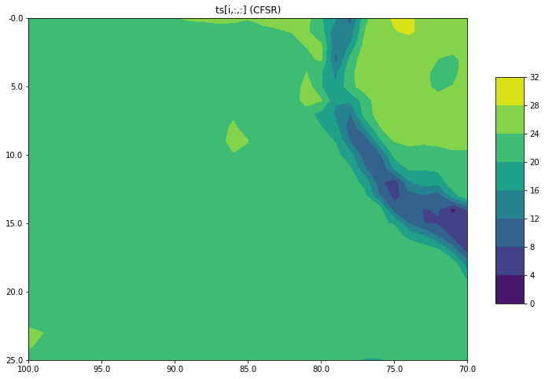

```python
## graficar dia 1

# Configurar el tamaño por defecto de la salida gráfica
plt.rcParams["figure.figsize"] = (10, 8)

# Grilla horizontal
ylab = lat0[lat0%5 == 0]
xlab = lon0[lon0%5 == 0]

plt.contourf(var0[0,:,:]-273.15)

plt.xticks(ticks=[0,5,10,15,20,25,30],labels=360-xlab)
plt.yticks(ticks=[0,5,10,15,20,25],labels=-ylab)
plt.title(label='ts[i,:,:] (CFSR)')

cax = plt.axes([0.95, 0.25, 0.05, 0.5])
plt.colorbar(cax=cax)
```

```python
## Modelos CMIP6
# 1: IPSL-CM6A-LR
# 2: MPI-ESM1-2-HR
# 3: MPI-ESM1-2-LR
ruta_modelo = archivos['ts'][3]
file2read = netcdf.NetCDFFile(ruta_modelo,'r')

file2read.variables.keys()
```

```
dict_keys(['time', 'time_bnds', 'longitude', 'latitude', 'height', 'tas'])
```

```python
## Dimensiones: time,lat,lon
# time: days 0:7669 desde 01-01-1990 a 31-12-2010
# lat: °S 0:24 desde 0 a 25
# lon: °W 1:101 desde 70 a 100
time = file2read.variables["time"]
lat0 = file2read.variables["latitude"][:]
lon0 = file2read.variables["longitude"][:]

## solo hay una variable: 'tas'
var = file2read.variables["tas"]
var1 = var[:].__copy__()
del var

# cerrar archivo netcdf
file2read.close()
```

```python
var1.shape
```

```
(7670, 26, 31)
```

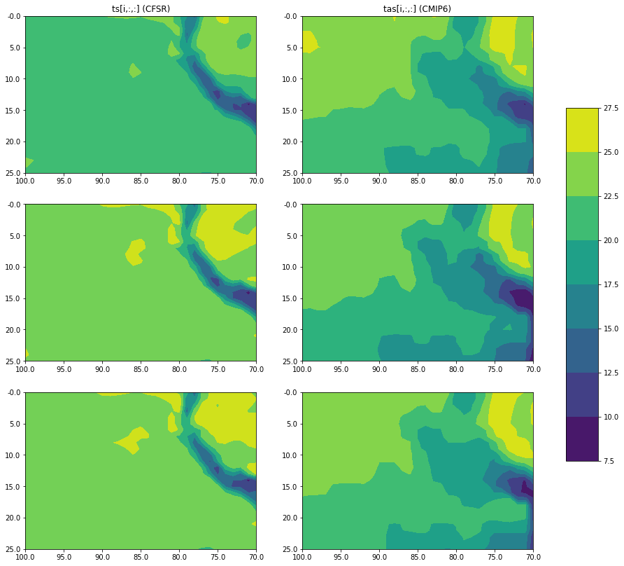

```python
plt.rcParams["figure.figsize"] = (13,14)
ax = plt.subplot(321)
i=0
plt.contourf(var0[i,:,:]-273.15)
plt.xticks(ticks=[0,5,10,15,20,25,30],labels=360-xlab)
plt.yticks(ticks=[0,5,10,15,20,25],labels=-ylab)
plt.title(label='ts[i,:,:] (CFSR)')
plt.subplot(322)
plt.contourf(var1[i,:,:]-273.15)
plt.xticks(ticks=[0,5,10,15,20,25,30],labels=360-xlab)
plt.yticks(ticks=[0,5,10,15,20,25],labels=-ylab)
plt.title(label='tas[i,:,:] (CMIP6)')
i=1
plt.subplot(323)
plt.contourf(var0[i,:,:]-273.15)
plt.xticks(ticks=[0,5,10,15,20,25,30],labels=360-xlab)
plt.yticks(ticks=[0,5,10,15,20,25],labels=-ylab)
plt.subplot(324)
plt.contourf(var1[i,:,:]-273.15)
plt.xticks(ticks=[0,5,10,15,20,25,30],labels=360-xlab)
plt.yticks(ticks=[0,5,10,15,20,25],labels=-ylab)
i=2
plt.subplot(325)
plt.contourf(var0[i,:,:]-273.15)
plt.xticks(ticks=[0,5,10,15,20,25,30],labels=360-xlab)
plt.yticks(ticks=[0,5,10,15,20,25],labels=-ylab)
plt.subplot(326)
plt.contourf(var1[i,:,:]-273.15)
plt.xticks(ticks=[0,5,10,15,20,25,30],labels=360-xlab)
plt.yticks(ticks=[0,5,10,15,20,25],labels=-ylab)
#colorbar
cax = plt.axes([0.95, 0.25, 0.05, 0.5])
plt.colorbar(cax=cax)
plt.show()
```

### Estadísticas del diagrama de Taylor

**Modulo SkillMetrics**

Se debe instalar la librería [SkillMetrics](https://pypi.org/project/SkillMetrics/). Por ejemplo en Linux, en una consola ejecutar

```
 sudo pip3 install SkillMetrics
```

```python
# librería que grafica el diagrama de Taylor
import skill_metrics as sm
```

```python
stats = OrderedDict()
```

```python
np.nanmean(var0-273.15)
#np.nanstd(var0-273.15)
```

```
21.56685
```

```python
diff1 = var1 - var0
```

```python
stats["bias"] = [0,np.nanmean(diff1)]
stats["bias"]
```

```
[0, -0.6882998]
```

```python
stats['sdev'] = [np.nanstd(var0),np.nanstd(var1)]
stats['sdev']
```

```
[3.893701, 3.5018702]
```

```python
stats["rmsd"] = [0,np.sqrt(np.nanmean(np.square(diff1)))]
stats["rmsd"]
```

```
[0, 2.5086882]
```

```python
## Fórmula CRMSD
# pmean = np.nanmean(predicted)
# rmean = np.nanmean(reference)
# crmsd = np.sqrt( np.sum( np.square((predicted - pmean) - (reference - rmean)) )/predicted.size )

## CRMSD
stats["crmsd"] = [0,np.sqrt(np.nanmean(np.square(diff1 - np.nanmean(diff1))))]
stats["crmsd"]
```

```
[0, 2.4124174]
```

Correlación en python:

- [Para vectores/columnas](https://realpython.com/numpy-scipy-pandas-correlation-python/)
- Para cubos de datos:

$$ \rho_{xy} = {\frac {\sum_t \sum_j \sum_i (x_{tji}-{\bar {x}})(y_{tji}-{\bar {y}})}{{\sqrt {\sum_t \sum_j \sum_i (x_{tji}-{\bar {x}})^{2}}}{\sqrt {\sum_t \sum_j \sum_i (y_{tji}-{\bar {y}})^{2}}}}}. $$

```python
# Get correlation coefficient (r)
diff_0  = var0 - np.nanmean(var0)
diff_1  = var1 - np.nanmean(var1)
ccoef = np.nansum(diff_0 * diff_1)/(np.sqrt(np.nansum(np.square(diff_0))) * np.sqrt(np.nansum(np.square(diff_1))))
stats['ccoef'] = [1,ccoef]
stats['ccoef']
```

```
[1, 0.7922211]
```

```python
stats['ID'] = ['CFSR','MPI-ESM1-2-LR']
stats
```

```
OrderedDict([('bias', [0, -0.6882998]),
             ('sdev', [3.893701, 3.5018702]),
             ('rmsd', [0, 2.5086882]),
             ('crmsd', [0, 2.4124174]),
             ('ccoef', [1, 0.7922211]),
             ('ID', ['CFSR', 'MPI-ESM1-2-LR'])])
```

```python
ccoef = np.array(stats['ccoef'])
ccoef
```

```
array([1.        , 0.79222113])
```

```python
sdev = np.array(stats['sdev'])
sdev
```

```
array([3.893701 , 3.5018702], dtype=float32)
```

```python
crmsd = np.array(stats['crmsd'])
crmsd
```

```
array([0.        , 2.41241741])
```

```python
## Verificar la ecuación
# abs(CRMSDs(1:)^2 - (STDs^2 + STDs(1:)^2 - 2*STDs*STDs(1:)*CORs(1:)))/CRMSDs(1:)^2

np.abs(crmsd[1:]**2- (sdev[0]**2 + sdev[1:]**2 - 2*sdev[0]*sdev[1:]*ccoef[1:]) )/(crmsd[1:]**2)
#sm.check_taylor_stats(sdev, crmsd, ccoef, threshold = 0.001)
```

```
array([3.53295166e-07])
```

### Diagrama de Taylor de los modelos CMIP6

#### Un modelo

```python
# Estadisticas del diagrama de Taylor
label = stats['ID'][:2]

print(sdev)
print(crmsd)
print(ccoef)
print(label)
```

```
[3.893701  3.5018702]
[0.         2.41241741]
[1.         0.79222113]
['CFSR', 'MPI-ESM1-2-LR']
```

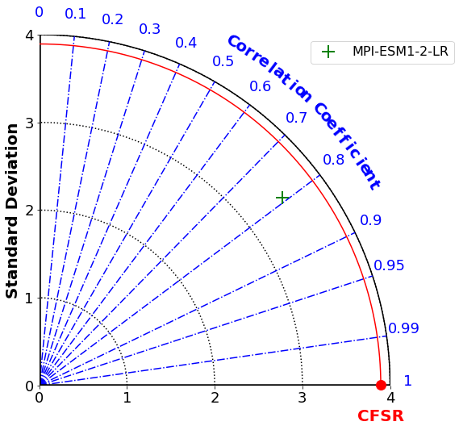

```python
plt.rcParams["figure.figsize"] = (8,8)
plt.rcParams["font.size"] = "18"

plt.figure(num=1)
## MarkedDisplayed:
# 'marker' (default): Experiments are represented by individual symbols
# 'colorBar': Experiments are represented by a color described in a colorbar
sm.taylor_diagram(sdev,crmsd,ccoef,
                  markerLabel = label,
                  markerLabelColor = 'g',
                  markerLegend = 'on', # Use legend for markers
                  markerColor = 'g',
                  markerSize = 16, # Marker size (Default: 10)
                  styleOBS = '-',
                  colOBS = 'r',
                  markerobs = 'o',
                  tickRMS = [0.0], tickRMSangle = 120,
                  showlabelsRMS = 'off', titleRMS = 'off',
                  titleOBS = 'CFSR')
# Show plot
plt.show()
```

#### Varios (3) modelos

```python
## Leer archivos y calcular estadísticas
## Modelos CMIP6
# 1: IPSL-CM6A-LR
# 2: MPI-ESM1-2-HR
# 3: MPI-ESM1-2-LR

file2read = netcdf.NetCDFFile(archivos['ts'][0],'r')
time = file2read.variables["time"]
lat0 = file2read.variables["latitude"][:]
lon0 = file2read.variables["longitude"][:]
var = file2read.variables["ts"]
var0 = var[:].__copy__()
ts_stats = OrderedDict()
ts_stats['sdev'] = [np.nanstd(var0)]
ts_stats["crmsd"] = [0]
ts_stats['ccoef'] = [1]
ts_stats['ID'] = ['CFSR','IPSL-CM6A-LR', 'MPI-ESM1-2-HR', 'MPI-ESM1-2-LR']

for i in range(1,4):
    file2read = netcdf.NetCDFFile(archivos['ts'][i],'r')
    var = file2read.variables["tas"]
    var1 = var[:].__copy__()
    diff1 = var1 - var0
    ts_stats['sdev'].append(np.nanstd(var1))
    ts_stats["crmsd"].append(np.sqrt(np.nanmean(np.square(diff1 - np.nanmean(diff1)))))
    diff_0  = var0 - np.nanmean(var0)
    diff_1  = var1 - np.nanmean(var1)
    ccoef = np.nansum(diff_0 * diff_1)/(np.sqrt(np.nansum(np.square(diff_0))) * np.sqrt(np.nansum(np.square(diff_1))))
    ts_stats['ccoef'].append(ccoef)

file2read.close()
del var, file2read
ts_stats
```

```
OrderedDict([('sdev', [3.893701, 4.015945, 4.039268, 3.5018702]),
             ('crmsd', [0, 2.333748, 1.9497586, 2.4124174]),
             ('ccoef', [1, 0.82632613, 0.8798182, 0.7922211]),
             ('ID',
              ['CFSR', 'IPSL-CM6A-LR', 'MPI-ESM1-2-HR', 'MPI-ESM1-2-LR'])])
```

```python
# Estadisticas del diagrama de Taylor
sdev = np.array(ts_stats['sdev'])
#sdev = np.array(ts_stats['sdev']/ts_stats['sdev'][0])
crmsd = np.array(ts_stats['crmsd'])
ccoef = np.array(ts_stats['ccoef'])
label = ts_stats['ID']
```

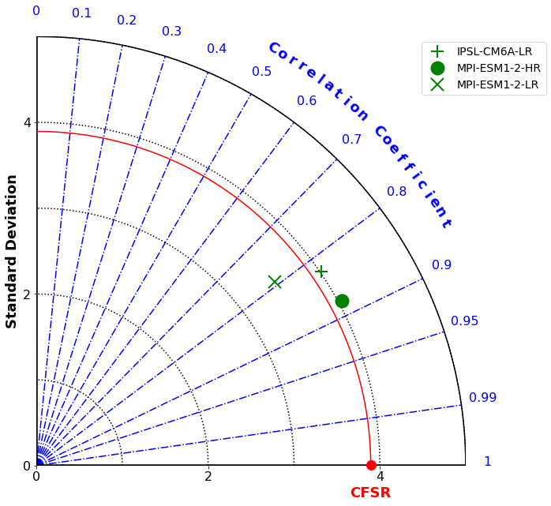

```python
plt.rcParams["figure.figsize"] = (10,10)
plt.rcParams["font.size"] = "16"
plt.figure(num=1)
sm.taylor_diagram(sdev,crmsd,ccoef,
                  markerLabel = label,
                  markerLabelColor = 'g',
                  markerLegend = 'on', # Use legend for markers
                  markerColor = 'g',
                  markerSize = 16, # Marker size (Default: 10)
                  styleOBS = '-',
                  colOBS = 'r',
                  markerobs = 'o',
                  tickRMS = [0.0], tickRMSangle = 120,
                  showlabelsRMS = 'off', titleRMS = 'off',
                  titleOBS = 'CFSR')
plt.show()
```

## Más hechos acerca de modelos climáticos

### Modelos globales

- Sistema acoplado: componente atmosférica-componente oceánica
- Reporte de evaluación del IPCC

[figure not shown]

### Modelos regionales

- Mayor resolución espacial y temporal
- Más costo computacional
- Ejemplo: WRF

[figure not shown]